# CH1

##### **CSPB 4830 - Special Topics: Coding Calculus**

### **Week #1 Workbook**

**Stephen Enriquez (@sten8791)**

### 1. Do the Reading Math Activity either from the video or office hours. Write a one page summary of your experience with the activity.

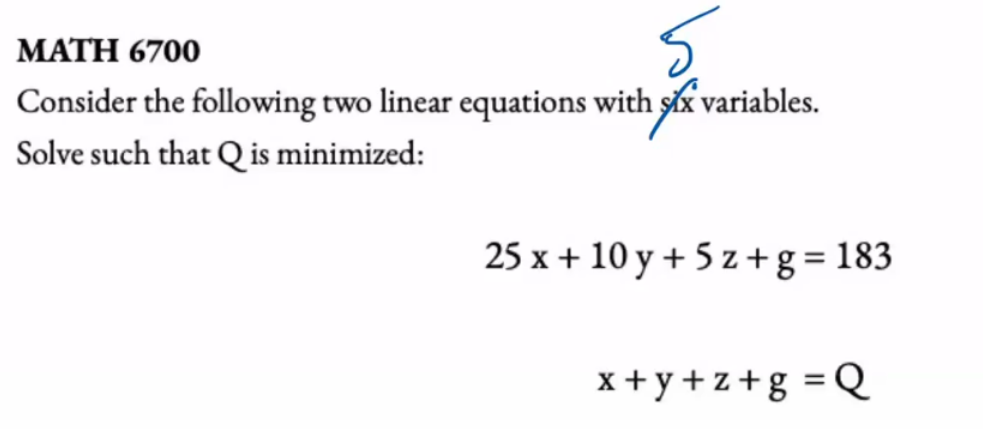

I was definitely puzzled at first. My mind quickly raced to an adage my old Physics professor used to preach: "Four equations, four unknowns". Yet here we are with four, or is it five, unknowns, and yet only two equations! Minimize? Maybe this is a calculus problem? What are we optimizing and against what? What is Q?

During office hours I just stared at this for a bit. Surely something was missing?

And then Prof. Stade continued along with the following:

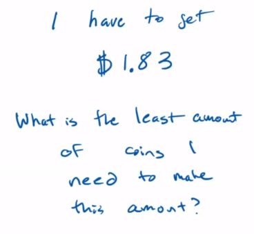

It took me a minute but I eventually saw the pattern, that Q represents the total number of coins and that each unit of x, y, z and g correspond to cent-values. And that the 183 equals $1 and 83 cents.

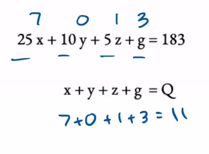

Minimizing for Q is the exact same as "arriving at the total with the least amount of coins".

This definitely surprised me, as the coin counting example made complete sense and felt intuitive, yet when presented in the initial "professional" format, I struggled to even place myself within the problem.

Once I looked at the equations again after going through the coin counting example, I realized how much simpler the problem actually is. The way that the problem was presented made a huge difference in how I approached the solution. This exercise made me realize that I'm not wholly comfortable with the "mathematics" language and that I found myself intimidated by the "linear equation" and the seeming lack of information.

I like that this exercise demonstrates the importance of how we "understand" the problem. And that the translation from "meaning" into mathematical language is part of the art of mathematics itself.

### 2. CODING: Create Python code for the SIR algorithm in section 1.3, you may use this to answer the remaining questions.

Using the structure provided in section 1.3, we can write the following code. For modularity, we create a function that can calculate S,I,R values and return vectors which we can then plot with a second function.

```python
"""
Returns vectors for t, S, I and R as modeled by the SIR algorithm.
"""
def model_SIR():

    # initialize lists as vectors for tracking variable data
    t_data = []
    S_data = []
    I_data = []
    R_data = []

    # set time parameters
    delta_t = 1 # time increment in days
    t_initial = 0
    t_final = 30

    # set initial values
    t = t_initial
    S = 45400 # Susceptible
    I = 2100 # Infected
    R = 2500 # Recovered

    # in this model, S + I + R = P (total population)

    a = .00002 # a = qp ; the effective contact rate, q = fraction of contact that actually lead to new infections, p = contacts with infected population
    b = (1/14) # 14 days to recover

    # store initial data points
    t_data.append(t)
    S_data.append(S)
    I_data.append(I)
    R_data.append(R)

    for i in range(t_initial, t_final):
        # Step1: S, I, R Rate Equations OR Dynamical System
        Sprime = -a * S * I  # decrease population in S per day, Susceptible turned Infectious
        Iprime = (a * S * I) - (I * b)  # changes in population I per day, balance of input from Susceptible AND output to Recovered
        Rprime = (I * b)    # increase population in R per day, Infectious turned Recovered

        # Step2: Central Principle Calculus in 9 words "net change equals rate of change times elapsed time"
        delta_S = Sprime * delta_t
        delta_I = Iprime * delta_t
        delta_R = Rprime * delta_t

         # update the data with deltas
        t = t + delta_t
        S = S + delta_S
        I = I + delta_I
        R = R + delta_R

        # update vectors
        t_data.append(t)
        S_data.append(S)
        I_data.append(I)
        R_data.append(R)

    return (t_data, S_data, I_data, R_data)


"""Generates a plot for the SIR model given data vectors for t, S, I and R.
"""
def plot_model(t_data, S_data, I_data, R_data):
    import matplotlib.pyplot as plt

    # plot the data
    fig, ax = plt.subplots()
    t_initial = t_data[1] # first element of t_data is t_initial
    t_final = t_data[-1] # last element of t_data is t_final

    ax.plot(t_data, S_data, label='S', color='orange')
    ax.plot(t_data, I_data, label='I', color='red')
    ax.plot(t_data, R_data, label='R', color='green')

    ax.set_ylim(0, 50000)
    ax.set_xlim(t_initial, t_final)
    ax.set_xlabel('Days')
    ax.set_ylabel('Population')
    ax.legend()

    fig.tight_layout()
    plt.show()
```

Now we can generate a model for S, I and R given initial values and a value for k and deltat.

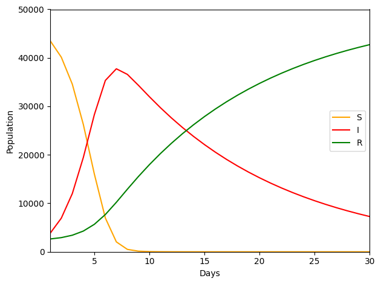

```python
# call our model_SIR function to populate our model
t_data, S_data, I_data, R_data = model_SIR()

# call our plot function to plot
plot_model(t_data, S_data, I_data, R_data)
```

### 1.1 #1 - #6

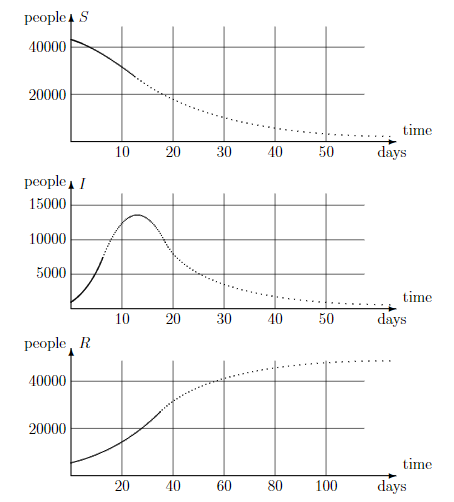

- 1. When does the infection hit its peak? How many people are infected at that time?

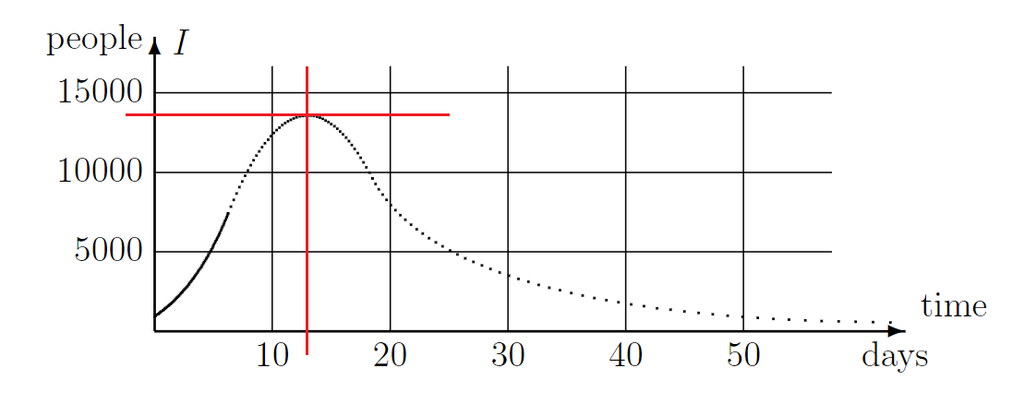

From the Infection graph, we can estimate that the infection hits its peak between 12 and 13 days into the epidemic. At this peak, around 13500 people are infected.

- 2. Initially, how many people are susceptible? How many days does it take for the susceptible population to be cut in half?

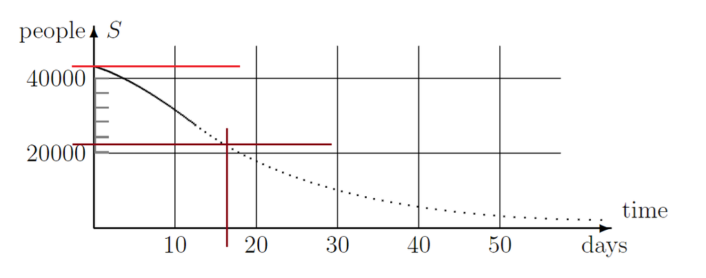

Initially, around 44000 people are susceptible. To reach half of this value (around 22,000), it takes roughly 17 days.

- 3. How many days does it take for the recovered population to reach 25,000? How many people eventually recover? Where did you look to get this information?

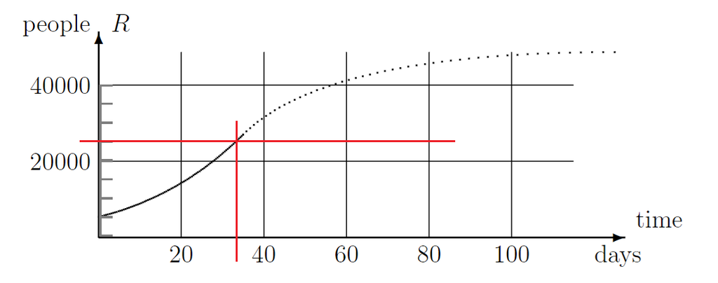

It takes roughly 34 days for the recovered population to reach 25,000. By looking at where the slope plateaus in the map it looks like around 50,000 people eventually recover, although there is no direct way to measure from the given graph.

- 4. On what day is the size of the infected population increasing most rapidly? When is it decreasing most rapidly? How do you know?

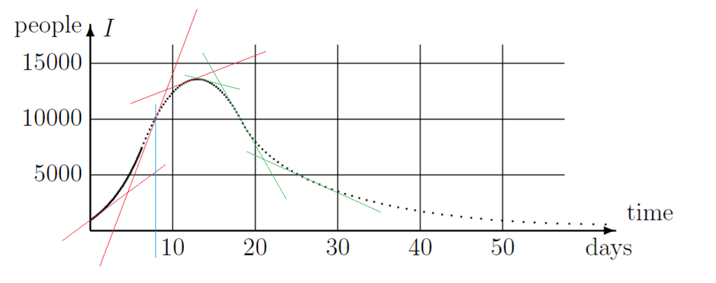

By looking at the relative slopes of the Infection curve, we can infer the value of I', which tells us the rate at which the infected population is rising. The slope looks to be steepest (increasing rapidly) right after day 8. Similarly, on its decline, the slope is steepest (decreasing rapidly) around day 19.

- 5. How many people caught the illness at some time during the first 20 days? (Note that this is not the same as the number of people who are infected on day 20.) Explain where you found this information.

- 6. Copy the graph of R as accurately as you can, and then superimpose a sketch of S on it. Notice the time scales on the original graphs of S and R are different. Describe what happened to the graph of S when you superimposed it on the graph of R. Did it get compressed or stretched? Was this change in the horizontal direction or the vertical?

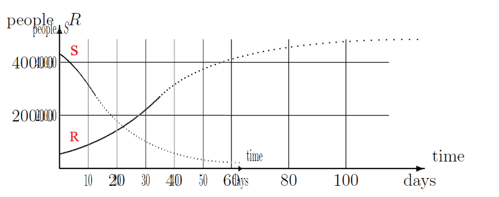

When I superimposed the graph of S onto R, I had to adjust the graph in order to match the same time scales (20 days = 20 days). Doing so results in the graph being compressed horizontally.

## 1.1 #7 7. These questions concern the rate equation S'= −470 persons per day that we used to model a susceptible population on pages 4–6.

Suppose the initial susceptible population was 20,000 on Wednesday. Use the model to answer the following questions.

- a) How many susceptibles will be left ten days later?

We can follow the model to tabulate the susceptible population at 10 days.

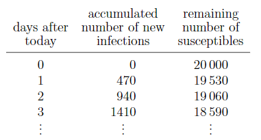

```python
from tabulate import tabulate
t = 0
P = 20000
I = 0
table_ = []
table_.append(["days after today","accumulated number of new infections", "remaining susceptibles"])

for i in range (0, 11):
    S = 20000 - 470 * t
    I = P - S
    row_ = [t, I, S]
    table_.append(row_)
    t = t + 1

print(tabulate(table_))
```

```
----------------  ------------------------------------  ----------------------
days after today  accumulated number of new infections  remaining susceptibles
0                 0                                     20000
1                 470                                   19530
2                 940                                   19060
3                 1410                                  18590
4                 1880                                  18120
5                 2350                                  17650
6                 2820                                  17180
7                 3290                                  16710
8                 3760                                  16240
9                 4230                                  15770
10                4700                                  15300
----------------  ------------------------------------  ----------------------
```

Based on the table above, there will be **15,300** remaining susceptibles ten days later.

- b) How many days will it take for the susceptible population to vanish entirely?

```python
from tabulate import tabulate
t = 0
P = 20000
I = 0
table_ = []
table_.append(["days after today","accumulated number of new infections", "remaining susceptibles"])

while S >= 0:
    S = 20000 - 470 * t
    I = P - S
    row_ = [t, I, S]
    table_.append(row_)
    t = t + 1

print(tabulate(table_))
```

```
----------------  ------------------------------------  ----------------------
days after today  accumulated number of new infections  remaining susceptibles
0                 0                                     20000
1                 470                                   19530
2                 940                                   19060
3                 1410                                  18590
4                 1880                                  18120
5                 2350                                  17650
6                 2820                                  17180
7                 3290                                  16710
8                 3760                                  16240
9                 4230                                  15770
10                4700                                  15300
11                5170                                  14830
12                5640                                  14360
```

[output cut: 32 more lines]

It will take **43 days** for the remaining susceptibles to dip below zero.

- c) How many susceptibles were there on the previous Sunday? Assuming today is Wednesday.

```python
days = ["Wednesday", "Thursday", "Friday", "Saturday", "Sunday", "Monday", "Tuesday"]
# days[0] corresponds to Wednesday

from tabulate import tabulate
t = 0
P = 20000
I = 0
table_ = []
table_.append(["days before today", "day of week", "accumulated number of new infections", "remaining susceptibles"])

while t > -4:
    S = 20000 - 470 * t
    I = P - S
    row_ = [t, days[t], I, S]
    table_.append(row_)
    t = t - 1

print(tabulate(table_))
```

```
-----------------  -----------  ------------------------------------  ----------------------
days before today  day of week  accumulated number of new infections  remaining susceptibles
0                  Wednesday    0                                     20000
-1                 Tuesday      -470                                  20470
-2                 Monday       -940                                  20940
-3                 Sunday       -1410                                 21410
-----------------  -----------  ------------------------------------  ----------------------
```

There were **21,410 susceptibles** on the previous Sunday.

- d) How many days before Wednesday were there 30,000 susceptibles?

```python
from tabulate import tabulate
t = 0
P = 20000
I = 0
table_ = []
table_.append(["days before today", "accumulated number of new infections", "remaining susceptibles"])

while S <= 30000:
    S = 20000 - 470 * t
    I = P - S
    row_ = [t, I, S]
    table_.append(row_)
    t = t - 1

print(tabulate(table_))
```

```
-----------------  ------------------------------------  ----------------------
days before today  accumulated number of new infections  remaining susceptibles
0                  0                                     20000
-1                 -470                                  20470
-2                 -940                                  20940
-3                 -1410                                 21410
-4                 -1880                                 21880
-5                 -2350                                 22350
-6                 -2820                                 22820
-7                 -3290                                 23290
-8                 -3760                                 23760
-9                 -4230                                 24230
-10                -4700                                 24700
-11                -5170                                 25170
-12                -5640                                 25640
-13                -6110                                 26110
-14                -6580                                 26580
-15                -7050                                 27050
-16                -7520                                 27520
-17                -7990                                 27990
-18                -8460                                 28460
-19                -8930                                 28930
-20                -9400                                 29400
-21                -9870                                 29870
-22                -10340                                30340
-----------------  ------------------------------------  ----------------------
```

From the table above, it looks like it was **22 days before Wednesday** that there were at least 30,000 susceptibles.

## 1.1 #19

**Quarantine.** One of the ways to treat an epidemic is to keep the infected away from the susceptible; this is called quarantine. The intention is to reduce the chance that the illness will be transmitted to a susceptible person. Thus, quarantine alters the transmission coefficient.

- a) Suppose a quarantine is put into effect that cuts in half the chance that a susceptible will fall ill. What is the new transmission coefficient?

The new transmission coefficient will be a/2, or half of the current value of a. In the book example, a is given as 0.00001, half of which would be a = 0.000005

- b) On page 18 it was determined that whenever there were fewer than 7143 susceptibles, the number of infected would decline instead of grow. We called 7143 a threshold level for S. Changing the transmission coefficient, as in part (a), changes the threshold level for S. What is the new threshold?

The threshold represents when I'= 0. We are given the following relationship:

I'= aSI −bI

Since I' = aSI - bI = 0, we can reduce this further to:

I' = 0 = aS - b

aS = b

Which means we can represent the threshold as a function of b and a:

S = b / a

Since the new transmission coeffient will be halved, the threshold will effectively double:

S = b / (a/2) = 2(b/a)

This means the new threshold must be double that of 7,143 = **14,286**

- c) Suppose we start with S = 45,400. Does quarantine eliminate the epidemic, in the sense that the number of infected immediately goes down from 2100, without ever showing an increase in the number of cases?

In order for the number of infected to immediately go down from 2100, the slope for "I" must be negative at the start, to indicate that I is decreasing. For I to decrease immediately, I' must be negative:

I' = aSI - bI < 0

If we start with S = 45400 and I = 2100, we can see if I' will be negative at the start with known a and b:

I' = I(aS - b) = 2100 (0.000005 * 45400 - 1/14) = 326.7

Beecause this value is positive, then no, I' will increase at the rate above.

- d) Since the new transmission coefficient is not small enough to guarantee that I never goes up, can you find a smaller value that does guarantee I never goes up? Continue to assume we start with S = 45400.

For I to decrease immediately, I' must be negative.

I' = aSI - bI

I' = I(aS - b) must be < 0

We observe here that the value for I has no consequence. The only way for the expression to return negative is if somehow, 'b' is larger than the 'aS', which would always result in a negative I'.

If we take b = 1/14 and S = 45400:

a * 45400 - 1/14 < 0

a < 1 / (14 * 45400) = **1 / 635,600** or 0.00000157

Any value for the transmission coefficient that is less than **1 / 635,600** will guarantee that I never goes up, such as 0.0000010

- e) Suppose the initial susceptible population is 45,400. What is the largest value that the transmission coefficient can have and still guarantee that I never goes up? What level of quarantine does this represent? That is, do you have to reduce the chance that a susceptible will fall ill to one-third of what it was with no quarantine at all, to one-fourth, or what?

To achieve this level of quarantine, we need to reduce the chance for a susceptible to fall ill by around **one-sixth or 1/6th** of current value. Given that a = qp, this would mean reducing the likelihood of contacts 'p' by a sixth.

## 1.1 #20

Suppose the spread of an illness similar to measles is modelled by the following rate equations:

S'= −.00002 SI,

I'= .00002 SI −.08 I,

R'= .08 I.

Note: the initial values S = 45400, etc. that we used in the text do not apply here.

- a) Roughly how long does someone who catches this illness remain infected? Explain your reasoning.

In the SIR model, the rate of recovery is given by R' = bI persons per day, where the constant b is called the recovery coefficient. From the given equation for R', we gather that b = 0.08.

The recovery coefficient is defined as how many infected persons will recover in 'k' days. Hence, if we have a given value for b:

b = 1/k k = 1/b = 1/0.08 = **12.5 days**

- b) How large does the susceptible population have to be in order for the illness to take hold—that is, for the number of cases to increase? Explain your reasoning.

For the illness to take hold, I' must be positive. We are given:

I' = aSI - bI

I' = I(aS - b) must be > 0

Again, the value for I has no consequence. The only way for the expression to return positive is if somehow, 'aS' is larger than 'b', which would always result in a positive I'.

From the given rate equations, we gather: a = 0.00002

b = 0.08

aS - B > 0

aS > B

S > B/a

s > 0.08/0.00002 > 4,000

The susceptible population needs to be at least **4,000** in order for the illness to take hold.

- c) Suppose 100 people in the population are currently ill. According to the model, how many (of the 100 infected) will recover during the next 24 hours?

According to the model, R' = bI = 0.08 * 100 = **8** people will recover during the next 24 hours (1 day).

- d) Suppose 30 new cases appear during the same 24 hours. What does that tell us about S'?

30 new cases per day means 30 fewer susceptibles in the same time period, thus S'= **−30 persons per day**.

- e) Using the information in parts (c) and (d), can you determine how large the current susceptible population is?

By algebra, we can calculate I from the rate equation S' = -aSI :

S = - S' / aI = -(-30) / (.00002 * 100) = 30 / 0.002 S = 15,000

The current susceptible population is **15,000 people**.

## 1.1 #21

a) Construct the appropriate S-I-R model for a measles-like illness that lasts for 4 days. It is also known that a typical susceptible person meets only about 0.3% of infected population each day, and the infection is transmitted in only one contact out of six.

We can model the transmission rate from the given information.

The fraction of contacts, p, is given as 0.003.

Only 1 out of 6 contacts transmit the infection which gives us q = 1/6.

From this we can calculate a = pq = 0.0005

Since the illness lasts for 4 days, we can also say that b = 1/4 = 0.25

From this, we can construct our S-I-R model:

- S' = -0.0005SI
- I' = 0.0005SI - 0.25I
- R' = 0.25 I

b) How small does the susceptible population have to be for this illness to fade away without becoming an epidemic?

For this illness to fade away without becoming an epidemic, the rate of increase of infections, I', must be less than zero.

We can say that: I' = aSI - bI must be less than 0

aSI - bI < 0

We can divide both sides by I:

aS - b < 0

aS < b

S < b/a

Using the values for a and b:

S < 0.25/0.0005

S < 500 people

The susceptible population has to be 500 people.

## 1.1 #22

Consider the general S-I-R model for a measles-like illness:

- S'= −aSI,
- I'= aSI −bI,
- R'= bI.

a) The threshold level for S—below which the number of infected will only decline—can be expressed in terms of the transmission coefficient a and the recovery coefficient b. What is that expression?

The threshold level can be expressed in terms of a and b as:

S < b/a

b) Consider two illnesses with the same transmission coefficient a; assume they differ only in the length of time someone stays ill. Which one has the lower threshold level for S? Explain your reasoning

The recovery coefficient, b, is inversely proportional to the length of time someone stays ill.

- The illness with a longer duration will have a lower recovery coefficient.
- The illness with a shorter duration will have a higher recovery coefficient.

The threshold level S, is directly proportional to the recovery coefficient.

- The illness with a longer duration will have a lower recovery coefficient, and thus, a lower threshold level.
- The illness with a shorter duration will have a higher recovery coefficient, and thus, a higher threshold level.